# FBI Crime Capstone Project Milestone Report

Ankita Hanmiah

February 7, 2019

### Introduction

The Federal Bureau of Investigation’s Uniform Crime Reporting program contains a plethora of data intended to provide information to law enforcement administration and the public on the prevalence of different crimes throughout the United States. Crimes that come to their attention are compiled into four collections of data: national incidents, crimes against law enforcement officials, hate crimes, and general criminal offenses. In this project, the focus is on general crime: violent and property crime. The intended questions to be answered are: which states are these crimes most prevalent in? Which are the “safest”" states and the most “dangerous”? Is there a relationship between violent and property crime? And does poverty share a relationship with crime?

This information would be beneficial for people, probably starting a family, who are looking for a place to put down roots that is safe for their family, or at the very least so that they may be informed and aware of the kind of crime that is most prevalent where they live. This would also be useful for law enforcement and state governments, so that they may be able to more thoroughly understand the current most widespread crime-related, and possibly poverty-related, issues within their jurisdiction. This information could help them build new laws, programs, or make reforms that move towards preventing these kinds of crimes within their state.

### Data and Data Wrangling

The original crime data used for this project was collected from Table 4 of the 2017 FBI UCR (FBI Crime Data - State and Region (Original).csv). The FBI compiled 24 tables of data for their offenses, with different breakdowns of regions, states, counties, cities, metropolitan versus non-metropolitan areas, suburban versus non-suburban areas, generalized location of the offenses, weapons used in violent crime, time of day for property crime, and other circumstances. There is additional expanded data on specific crimes as well as clearance data, providing information on how the case was closed: whether or not an arrest was made or if there was another circumstantial close to the case. The table used for this project contained data on the counts and rates of different criminal offenses, as well as counts and rates for violent and property crime, for each state plus the District of Columbia. Violent crime is defined by the FBI as “offenses that involve force or threat of force” and encompasses murder and nonnegligent manslaughter, aggravated assault, rape, and robbery. Property crime is defined as “offenses in which there is no force or threat of force against the victims” and includes burglary, larceny, and motor vehicle theft. The crime dataset being used contains data for 2016 and 2017, though only 2017 will be used for this project to determine what the most current answers are, as this is most beneficial to families and law enforcement looking to make current decisions.

The poverty data (Poverty_State2017 (Original).csv) is compiled by Census using their measures of determining which families fall within the poverty limit. This is measured by using sets of income thresholds that differs based on the size of the family and their composition. The family’s total income, before taxes and not including benefits, must be under the determined threshold for the family to be considered in poverty.

The data collected from the FBI UCR and Census was reorganized into three separate data sets: “FBICrime”(CrimeByState&Offenses.csv), “FBICrime2”(Violent&PropertyCrime.csv), and “CrimePoverty”(Crime&PovertyByState.csv):

```r
library(tidyverse)

FBICrime <- read_csv("FBI Crime Data - State and Region (Original).csv")
Poverty <- read_csv("Poverty_State2017 (Original).csv")

#With the poverty data, the columns to be used in this project were subset and renamed
poverty_names <- make.names(c("State", "Poverty Count", "Poverty Rate"))
Poverty <- Poverty[c("State / County Name", "All Ages in Poverty Count", "All Ages in Poverty Percent")] %>%
  setNames(poverty_names)
Poverty$State <- tolower(Poverty$State)

#The unnecessary data, extra rows, and empty columns were removed and the states, population, and crime data for 2017 was isolated
#Column names and certain state names were adjusted
FBICrime <- FBICrime %>%
  fill(Area) %>%
  filter(Year != "Percent change", Year != "2016", !is.na(Year)) %>%
  filter(!(Area %in% c("United States Total5, 6", "Puerto Rico", "Pacific", "Mountain", "West", "West South Central", "East South Central", "South Atlantic5,6", "South5,6", "West North Central", "East North Central", "Midwest", "Middle Atlantic", "Northeast", "New England"))) %>%
  arrange(Area)

column_names <- make.names(c("State", "Population", "Violent Crime", "Murder", "Rape", "Robbery", "Aggravated Assault", "Property Crime", "Burglary", "Larceny", "Motor Vehicle Theft"))
FBICrime <- FBICrime %>%
  select(Area, Population2, starts_with("X"), -X22, -X23, -X24) %>%
  setNames(column_names)

FBICrime$State[FBICrime$State %in% "District of Columbia5"] <- c("District of Columbia")
FBICrime$State[FBICrime$State %in% "North Carolina6"] <- c("North Carolina")

#Gathered the crimes into an offense column and separated rate to use for further wrangling
#Converted rates and population to numeric values after removing commas
FBICrime <- FBICrime %>%
  gather("Offense", "Rate", Violent.Crime:Motor.Vehicle.Theft)
FBICrime$Rate <- gsub(",", "", FBICrime$Rate) %>% as.numeric(FBICrime$Rate)
FBICrime$Population <- gsub(",", "", FBICrime$Population) %>%
  as.numeric(FBICrime$Population)
FBICrime$State <- tolower(FBICrime$State)

#Filtered Violent Crime and Property Crime into a separate data frame and removed them from the original dataset
#Spread out the offenses and rates in FBICrime to prepare the data for plotting and statistics
Violent_Crime <- filter(FBICrime, Offense == c("Violent.Crime"))
Property_Crime <- filter(FBICrime, Offense == c("Property.Crime"))
FBICrime2 <- bind_rows(Violent_Crime, Property_Crime) %>%
  arrange(State)

FBICrime <- FBICrime %>%
  spread(Offense, Rate) %>%
  select(-Violent.Crime, -Property.Crime)

#Created a separate dataset containing average total crime rates per state to append to the poverty data
#Spread out the offenses and rates in FBICrime2 to prepare the data for plotting and statistics
AvgStateRate <- FBICrime2 %>%
  group_by(State) %>%
  summarise(Average.Crime.Rate = mean(Rate))
FBICrime2 <- FBICrime2 %>% spread(Offense, Rate)

#Appended the average crime rates with the poverty data and adjusted decimal places
CrimePoverty <- left_join(AvgStateRate, Poverty, by = "State")
is.num <- sapply(CrimePoverty, is.numeric)
CrimePoverty[is.num] <- lapply(CrimePoverty[is.num], round, 1)

#Saved the three datasets to csv files
write.csv(FBICrime, file = "CrimeByState&Offenses.csv")
write.csv(FBICrime2, file = "Violent&PropertyCrime.csv")
write.csv(CrimePoverty, file = "Crime&PovertyByState.csv")
```

### Exploratory Data Analysis and Statistics

Looking at these data sets, some of the things that can be explored are comparisons between the rates of different categories of crime (violent crime and property crime), as well as the rate of crime between states for each of the different criminal offenses. To be able to visually see which states are most affected, the rates were mapped onto the fifty states: the higher rates are in brighter shades of teal whereas the lower rates are in shades of green leading to black.

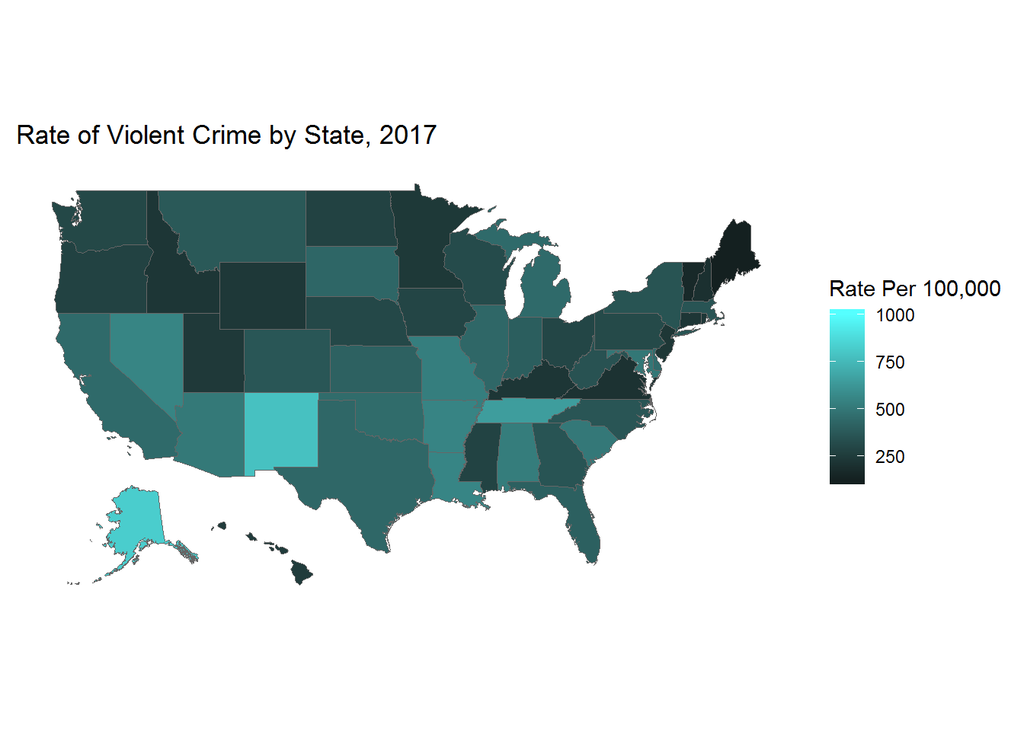

```r
library(fiftystater)

ggplot() +
  geom_map(aes(x = long, y = lat, map_id = id), data = fifty_states, map = fifty_states, size = 0.15) +
  geom_map(aes(fill = Violent.Crime, map_id = State), map = fifty_states, data = FBICrime2, color = "grey40", size = 0.15) +
  scale_fill_gradient2(name = "Rate Per 100,000", low = "black", mid = "black", high = "#55FFFF") +
  coord_map() + labs(x = NULL, y = NULL, title = "Rate of Violent Crime by State, 2017") +
  theme(axis.ticks = element_blank(), axis.text = element_blank(), panel.background = element_blank(), panel.border = element_blank())
```

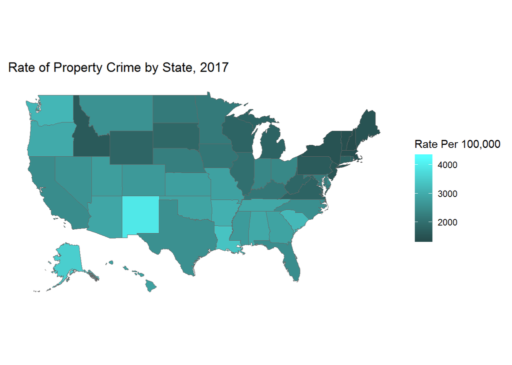

```r
ggplot() +
  geom_map(aes(x = long, y = lat, map_id = id), data = fifty_states, map = fifty_states, size = 0.15) +
  geom_map(aes(fill = Property.Crime, map_id = State), map = fifty_states, data = FBICrime2, color = "grey40", size = 0.15) +
  scale_fill_gradient2(name = "Rate Per 100,000", low = "black", mid = "black", high = "#55FFFF") +
  coord_map() + labs(x = NULL, y = NULL, title = "Rate of Property Crime by State, 2017") +
  theme(axis.ticks = element_blank(), axis.text = element_blank(), panel.background = element_blank(), panel.border = element_blank())
```

One of the trends that can be seen by looking at these maps is that there is a higher prevalence of property crime throughout the United States as compared to violent crime. While the scale of violent crime rates per 100,000 is from below 250 to over 1000, the scale for property crime rates per 100,000 is from below 2000 to over 4000.

These maps of generalized violent and property crime show that New Mexico and Alaska seem to have the highest rates of both violent and property crime. It can also be seen by the difference in scale and in the coloring that there are higher rates of property crime than violent and property crime is more highly widespread across the states than violent crime. Property crime seems to be most prevalent in the southern and western states, with the least amount in the northeast and parts of the midwest and mountain region, whereas violent crime is most prevalent in New Mexico, Alaska, and Tennessee, with mid to low rates across the rest of the states.

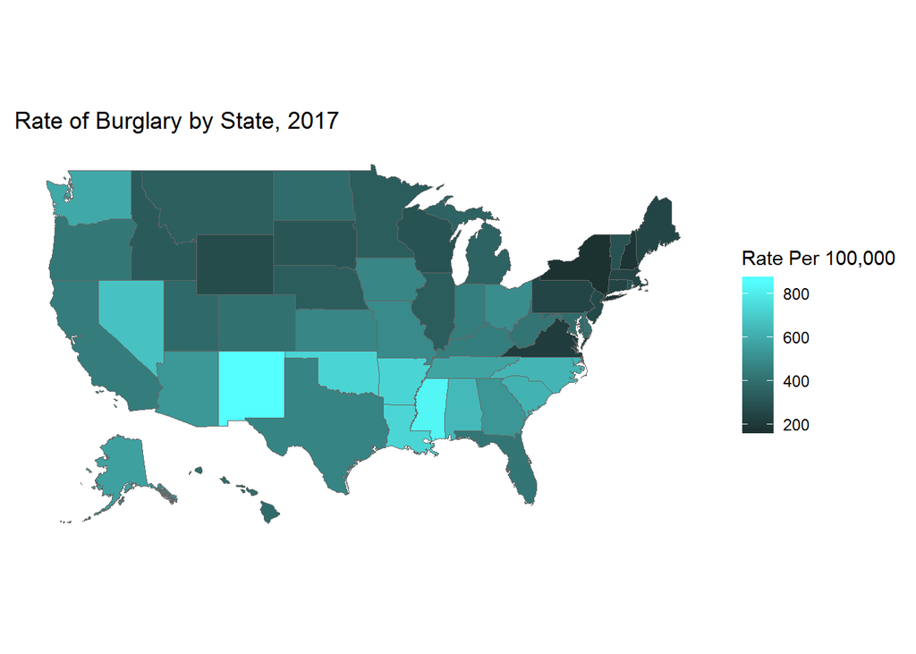

```r
ggplot() +
  geom_map(aes(x = long, y = lat, map_id = id), data = fifty_states, map = fifty_states, size = 0.15) +
  geom_map(aes(fill = Burglary, map_id = State), map = fifty_states, data = FBICrime, size = 0.15, color = "grey40") +
 scale_fill_gradient2(name = "Rate Per 100,000", low = "black", mid = "black", high = "#55FFFF") +
  coord_map() + labs(x = NULL, y = NULL, title = "Rate of Burglary by State, 2017") +
  theme(axis.ticks = element_blank(), axis.text = element_blank(), panel.background = element_blank(), panel.border = element_blank())
```

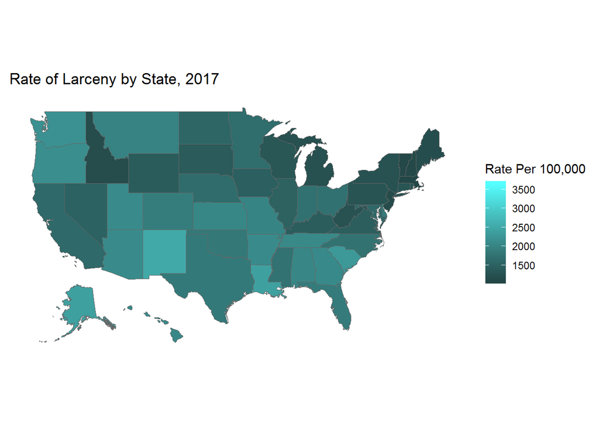

```r
ggplot() +
  geom_map(aes(x = long, y = lat, map_id = id), data = fifty_states, map = fifty_states, size = 0.15) +
  geom_map(aes(fill = Larceny, map_id = State), map = fifty_states, data = FBICrime, color = "grey40", size = 0.15) +
  scale_fill_gradient2(name = "Rate Per 100,000", low = "black", mid = "black", high = "#55FFFF") +
  coord_map() + labs(x = NULL, y = NULL, title = "Rate of Larceny by State, 2017") +
  theme(axis.ticks = element_blank(), axis.text = element_blank(), panel.background = element_blank(), panel.border = element_blank())
```

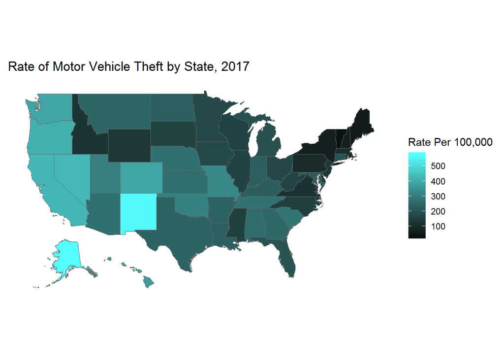

```r
ggplot() +
  geom_map(aes(x = long, y = lat, map_id = id), data = fifty_states, map = fifty_states, size = 0.15) +
  geom_map(aes(fill = Motor.Vehicle.Theft, map_id = State), map =fifty_states, data = FBICrime, color = "grey40", size = 0.15) +
  scale_fill_gradient2(name = "Rate Per 100,000", low = "black", mid = "black", high = "#55FFFF") +
  coord_map() + labs(x = NULL, y = NULL, title = "Rate of Motor Vehicle Theft by State, 2017") +
  theme(axis.ticks = element_blank(), axis.text = element_blank(), panel.background = element_blank(), panel.border = element_blank())
```

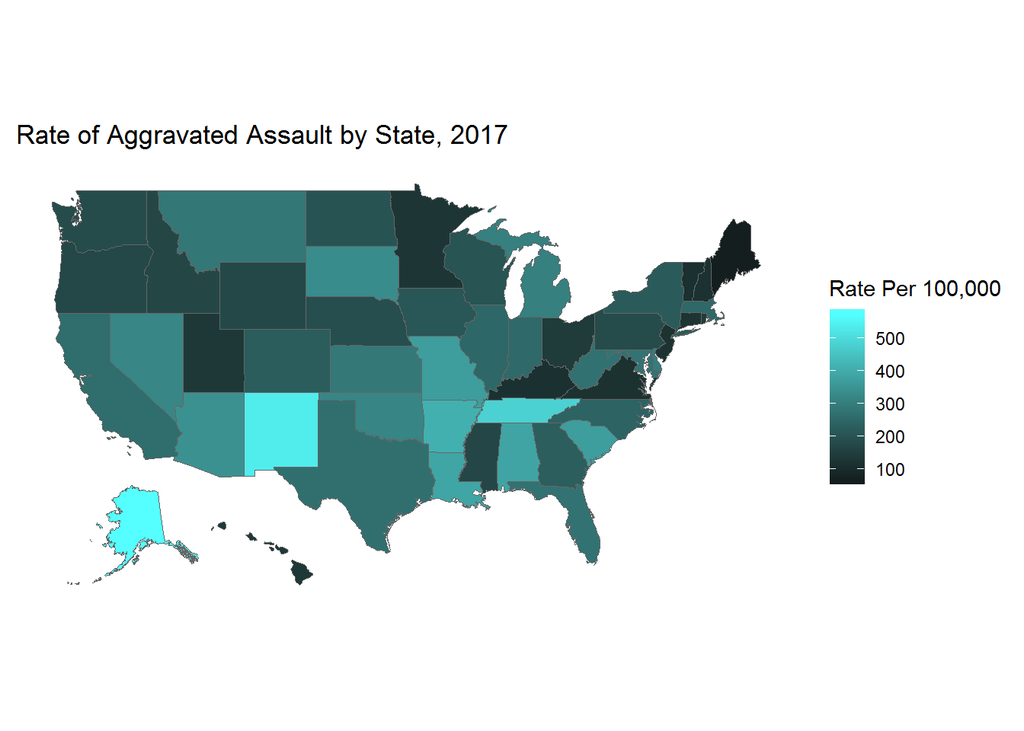

```r
ggplot() +
  geom_map(aes(x = long, y = lat, map_id = id), data = fifty_states, map = fifty_states, size = 0.15) +
  geom_map(aes(fill = Aggravated.Assault, map_id = State), map = fifty_states, data = FBICrime, color = "grey40", size = 0.15) +
  scale_fill_gradient2(name = "Rate Per 100,000", low = "black", mid = "black", high = "#55FFFF") +
  coord_map() + labs(x = NULL, y = NULL, title = "Rate of Aggravated Assault by State, 2017") +
  theme(axis.ticks = element_blank(), axis.text = element_blank(), panel.background = element_blank(), panel.border = element_blank())
```

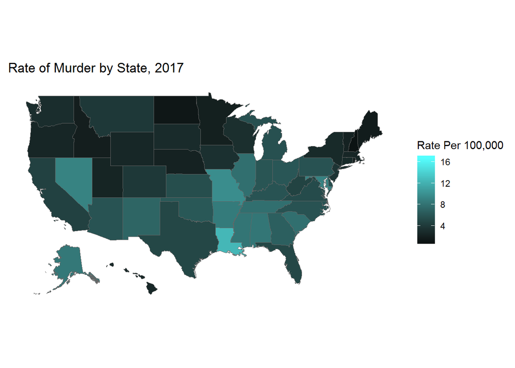

```r
ggplot() +
  geom_map(aes(x = long, y = lat, map_id = id), data = fifty_states, map = fifty_states, size = 0.15) +
  geom_map(aes(fill = Murder, map_id = State), map = fifty_states, data = FBICrime, color = "grey40", size = 0.15) +
  scale_fill_gradient2(name = "Rate Per 100,000", low = "black", mid = "black", high = "#55FFFF") +
  coord_map() + labs(x = NULL, y = NULL, title = "Rate of Murder by State, 2017") +
  theme(axis.ticks = element_blank(), axis.text = element_blank(), panel.background = element_blank(), panel.border = element_blank())
```

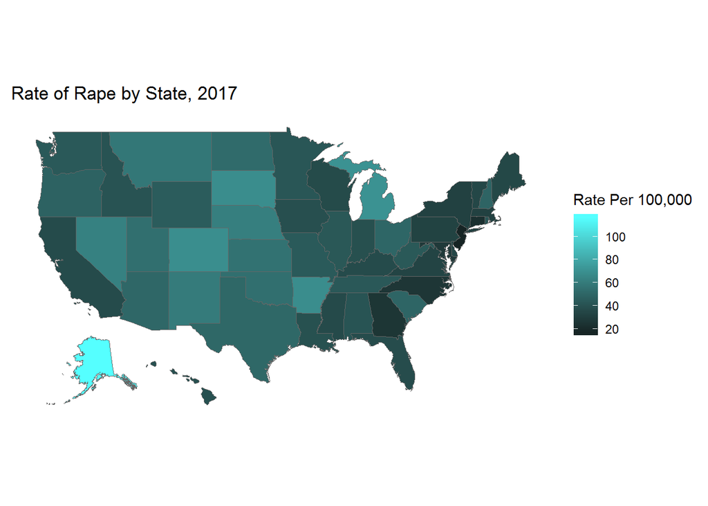

```r
ggplot() +
  geom_map(aes(x = long, y = lat, map_id = id), data = fifty_states, map = fifty_states, size = 0.15) +
  geom_map(aes(fill = Rape, map_id = State), map = fifty_states, data = FBICrime, color = "grey40", size = 0.15) +
 scale_fill_gradient2(name = "Rate Per 100,000", low = "black", mid = "black", high = "#55FFFF") +
  coord_map() + labs(x = NULL, y = NULL, title = "Rate of Rape by State, 2017") +
  theme(axis.ticks = element_blank(), axis.text = element_blank(), panel.background = element_blank(), panel.border = element_blank())
```

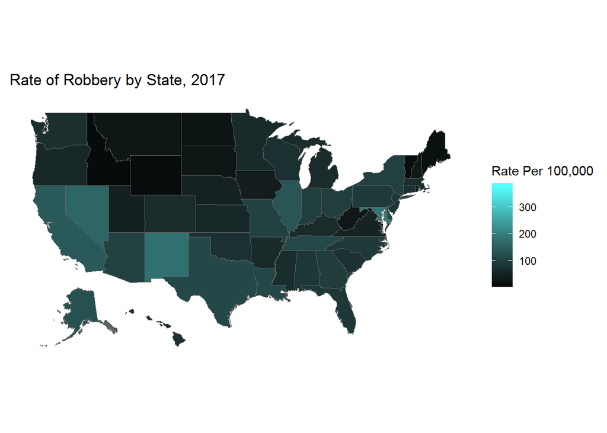

```r
ggplot() +
  geom_map(aes(x = long, y = lat, map_id = id), data = fifty_states, map = fifty_states, size = 0.15) +
  geom_map(aes(fill = Robbery, map_id = State), map = fifty_states, data = FBICrime, color = "grey40", size = 0.15) +
  scale_fill_gradient2(name = "Rate Per 100,000", low = "black", mid = "black", high = "#55FFFF") +
  coord_map() + labs(x = NULL, y = NULL, title = "Rate of Robbery by State, 2017") +
  theme(axis.ticks = element_blank(), axis.text = element_blank(), panel.background = element_blank(), panel.border = element_blank())
```

These maps depict the distribution of the individual criminal offenses throughout the states. Glancing at the rate scales, it can be seen that larceny seems to have a highest prevalence with rates in the thousands.

For property crimes:

Burglary shows high rates throughout the south, ranging from 500 to over 800 cases per 100,000, with the most highlighted states being New Mexico and Mississippi, followed by states like Oklahoma, Arkansas, and Louisiana. The lowest rates of burglary (ranging from below 200 to 250 per 100,000) seem to be in New York, New Hampshire, and Virginia.

Motor vehicle theft seems to be most prevalent in New Mexico and Alaska (with rates over 500 per 100,000), followed by the west coast states (Washington, Oregon, California) in the 400 to 500 range, as well as Nevada and Colorado. The lowest rates (below 100) look to be in the New England/northeast states (Maine, New Hampshire, Vermont, New York, and Pennsylvania.

For violent crimes:

Aggravated assault seems to show its highest rates of over 500 cases per 100,000 in New Mexico, Alaska, and Tennessee, followed by 400 to 500 rates in Arkansas, Louisiana, Missouri, Alabama, South Carolina, and South Dakota. The lowest prevalence (below 100) seems to be in Maine, followed by 100 to 200 per 100,000 rates in New Hampshire, Vermont, Connecticut, New Jersey, Virginia, Kentucky, Ohio, Minnesota, and Utah.

Murder seemes to be the least prevalent crime reported to the FBI with the lowest of crime rates at a range of 0 to over 16 cases per 100,000 people, showing mostly mid to low rates (from 0 to 12) throughout the United States. The higher murder rates are found in Louisiana, Nevada, Missouri, and Maryland. The lowest rates below 4 are seen in the New England/northeast region along with Hawaii, and states in the northern midwest and northwest such as Minnesota, North Dakota, Nebraska, Idaho, and Utah.

Rape shows highest prevalence rating over 100 per 100,000 in Alaska. Most other states show middle range rates (between 40 to 90 per 100,000) except for Connecticut and New Jersey, which stand out as the lowest rated states below 20, followed by Georgia and North Carolina in the 20 to 40 range.

Robbery is fairly low on its scale throughout the United States with rates below 150 except for states like Nevada, New Mexico, Maryland, and Illinois where you can probably find rates over 200.